# Practico 7

### Objetivos Práctico 7

- Calcule el área cubierta por agua en cada imagen del atormentado [Río Ucayali](https://drive.google.com/file/d/12IrBJLnsIyXG2WRtAq7TsqZSrk769jh7/view?usp=sharing)
- Calcule el índice de persistencia de agua (número de veces que un pixel tiene agua en una serie de tiempo) en el área de estudio y muestralo en una figura
- Diseñe cartografía estática o dinámica para mostrar cambios en el curso del Río Ucayali
- Diseñe gráfico para mostrar tendencia temporal de la superficie cubierta por agua

Formato y plazo de entrega:

- Archivo html autoexplicativo, con formato espectacular de Markdown, con los pasos seguidos para resolver el práctico.
- Debe comentar el código y usar títulos y subtítulos para guiar al lector
- Si diseña cartografía en QGIS, debe insertarla como imagen. Aquí código que pueden utilizar:

```
from IPython.display import Image, display

# Path to your image
image_path = r"C:\Users\usuario\Pictures\LaVenganzaSeraTerrible.png"

# Display the image
display(Image(filename=image_path))
```

- Plazo de entrega: viernes 5 de Julio de 2024

En este [link](https://drive.google.com/drive/folders/1o7fYPKoUvp3Xr07lsEAYxfeJc9nx4gaP?usp=sharing) hay algunas funciones que pueden serles útiles

# Práctico 7

## 1. Cálculo del área cubierta por agua

#### 1.1 Se deberan importar las librerias a ocupar

```python
import rasterio
import pandas as pd
import matplotlib.pyplot as plt
import matplotlib.cm as cm
import copy
import numpy as np
import glob
import leafmap.leafmap as leafmap
import rasterio
import os
from rasterio.plot import show
```

#### 1.2 Importar Funciones especificas

```python
import indicesrasters
import statsrasters
```

#### 1.3 Calcular el NDWI para todos los Rasters

```python
indicesrasters.indiceespectral(r"D:\Documentos\Magister en Recursos Hídricos\SIG_TIC\Semana_14\landsat",3,1,"ndwi")
```

```
Procesamiento completado.
```

#### 1.4 Clasificar valores en los archivos TIFF según criterio de umbral del NDWI y luego exportar los resultados clasificados como nuevos archivos TIFF

```python
# Esta función genera una variable que contenga los archivos tif que estan en ese directorio.
lista=glob.glob(r"D:\Documentos\Magister en Recursos Hídricos\SIG_TIC\Semana_14\landsat/ndwi/*.tif")

# Crear el directorio de salida
carpetaSalida = os.path.join(r"D:\Documentos\Magister en Recursos Hídricos\SIG_TIC\Semana_14\landsat/ndwi", "ndwi_clases")
os.makedirs(carpetaSalida, exist_ok=True)

#Se crea variable que abre la lista anterior contenida con archivos .tif
metaRaster=rasterio.open(lista[0])


# Iterar sobre cada archivo TIFF en la lista
for image in lista:
    # Abrir el archivo raster y leer la primera banda (NDWI en este caso)
    with rasterio.open(image) as metaRaster:
        arrayRaster = metaRaster.read(1)  # Leer la primera banda como array de Numpy

        # Crear una copia del array para clasificar el NDWI
        NDWI_clases = np.zeros_like(arrayRaster, dtype=np.int32)  # Inicializar array de clases

        # Clasificar los valores del NDWI
        NDWI_clases[np.where(arrayRaster < 0)] = 0  # Valores menores a 0 clasificados como 0
        NDWI_clases[np.where(arrayRaster >= 0)] = 1  # Valores mayores o iguales a 0 clasificados como 1

        # Definir el perfil (metadata) para la nueva imagen
        profile = metaRaster.profile
        profile["dtype"] = "int32"  # Cambiar el tipo de datos a int32
        profile["count"] = 1  # Número de bandas

        # Crear la ruta de salida para el archivo clasificado
        output_path = os.path.join(carpetaSalida, os.path.basename(image)[:-4] + "_clases.tif")

        # Exportar la imagen clasificada en formato TIFF
        with rasterio.open(output_path, 'w', **profile) as export:
            export.write(NDWI_clases.astype(rasterio.int32), 1)  # Escribir la primera banda

print("Imágenes exportadas con éxito.")
```

```
Imágenes exportadas con éxito.
```

#### 1.5 Calculando el área cubierta por agua

| NDWI_clase | pixels | areakm2 |
| --- | --- | --- |
| 0 | 251364 | 1.643031e-07 |
| 1 | 11405 | 7.454832e-09 |

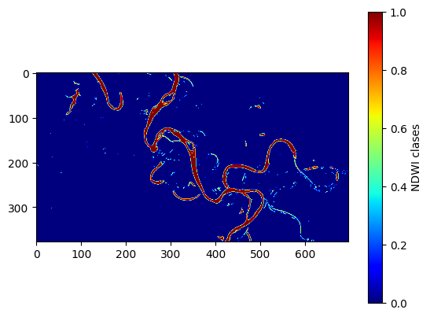

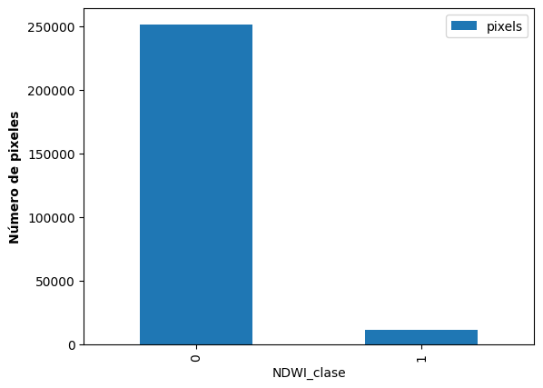

```python
#Visualización de archivos raster clasificados anteriormente
plt.imshow(NDWI_clases,cmap="jet")
plt.colorbar(label="NDWI clases");

##Convertimos array de numpy a DataFrame de Pandas para facilitar el análisis
clases= pd.DataFrame(NDWI_clases.flatten(),columns=["NDWI_clase"]) #Flatten permite convertir una matriz (i.e. múltiples filas y columnas) en una sola columna de datos
clases["pixels"]=1
sum_clases= pd.pivot_table(clases,index=["NDWI_clase"],values=["pixels"],aggfunc="sum")
sum_clases.plot(kind="bar")
plt.ylabel("Número de pixeles",fontweight="bold")

# Calculando el área en km^2
pixel_size = metaRaster.transform[0]
sum_clases['areakm2'] = ((pixel_size**2) * sum_clases['pixels']) / 1e6
sum_clases
```

## 2. Indice de Persistencia del Agua

#### 2.1 Suma de pixeles que presentan agua constantemente en la serie de tiempo

```python
# Ruta del directorio donde se encuentran los archivos NDWI clasificados
folder_path = r"D:\Documentos\Magister en Recursos Hídricos\SIG_TIC\Semana_14\landsat\ndwi\ndwi_clases"

# Tipo de cálculo (en este caso 'sum' para sumar los valores de todos los rasters)
calc = "sum"

# Cuantil para el cálculo (no se usa para 'sum')
quantil = 0.9

# Llamar a la función statsrasters.multiple_raster para obtener el resultado
result_path = statsrasters.multiple_raster(folder_path, calc, quantil)
print("Cálculo completado con éxito.")
```

[output not shown]

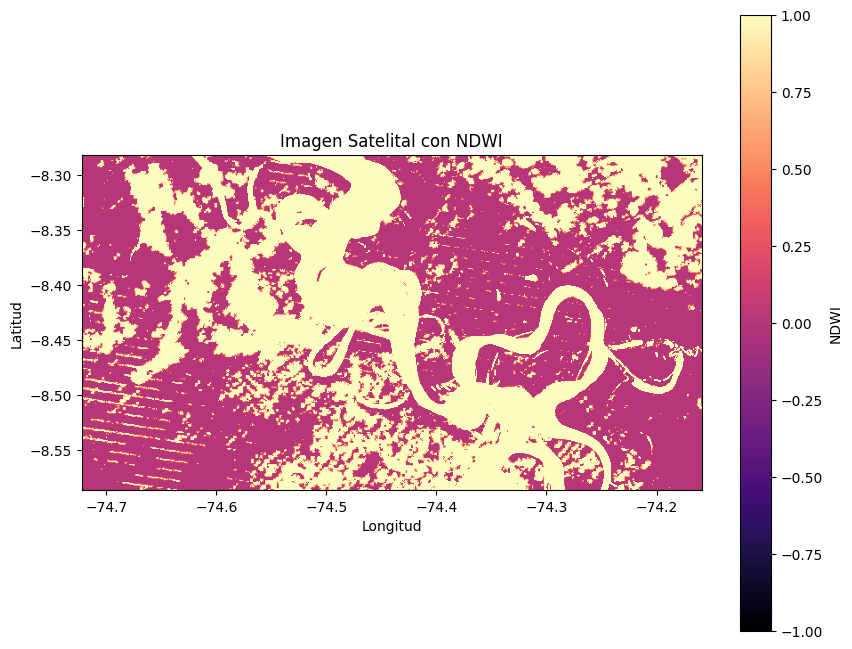

```python
# Ruta al archivo sum.tif
sum_tif_path = r"D:\Documentos\Magister en Recursos Hídricos\SIG_TIC\Semana_14\landsat\ndwi\ndwi_clases\sum\sum.tif"

try:
    # Abrir el archivo GeoTIFF con rasterio para visualizar
    with rasterio.open(sum_tif_path) as src:
        ndwi_band = src.read(1)  # Leer la primera banda (normalmente única en NDWI)
        transform = src.transform  # Obtener la transformación

        # Mostrar la imagen con Matplotlib
        plt.figure(figsize=(10, 8))
        img_plot = plt.imshow(ndwi_band, cmap='magma', extent=(transform[2], transform[2] + transform[0] * src.width,
                                                                 transform[5] + transform[4] * src.height, transform[5]),
                              vmin=-1.0, vmax=1.0)
        plt.colorbar(img_plot, label='NDWI')
        plt.title('Imagen Satelital con NDWI')
        plt.xlabel('Longitud')
        plt.ylabel('Latitud')
        plt.show()

except Exception as e:
    print(f"Error al abrir o visualizar el archivo GeoTIFF {sum_tif_path}: {e}")
```

## 3. Cartografía dinámica, para identificar cambios en el Rio Ucayala

#### 3.1 Creando mapa dinámico que muestra diferencias del Rio Ucayala desde 1984 a 2022

```python
#Debes posicionar las rutas de las dos imagenes en contraste que se proyectaran en un mapa base definido
leafmap.split_map(
    left_layer=r"D:\Documentos\Magister en Recursos Hídricos\SIG_TIC\Semana_14\landsat\ndwi\ndwi_clases\1984_ndwi_clases.tif",
    right_layer=r"D:\Documentos\Magister en Recursos Hídricos\SIG_TIC\Semana_14\landsat\ndwi\ndwi_clases\2022_ndwi_clases.tif",
    left_label="1984",  # Etiqueta del panel izquierdo
    right_label="2022",  # Etiqueta del panel derecho
    label_position="top",  # Posición de las etiquetas
    center=[-8.35414, -74.53827],  # Centro del mapa
    zoom=10,  # Nivel de zoom inicial
    split_type="blender"  # Tipo de mapa: swipe

)
```

```
Map(center=[-8.35414, -74.53827], controls=(ZoomControl(options=['position', 'zoom_in_text', 'zoom_in_title', …
```

#### 3.2 Creando mapa interactivo de la serie de tiempo

```python
#Posicionas la ruta de la carpeta que contenga la serie de tiempo
images = r"D:\Documentos\Magister en Recursos Hídricos\SIG_TIC\Semana_14\landsat\ndwi\ndwi_clases"
m = leafmap.Map()
m.add_time_slider(
    images,
    time_interval=0.5,
    position="bottomright",
    band=[1, 2, 3],
    zoom_to_layer=True,
)
```

## 4. Gráfico que muestre tendencia temporal de la superficie cubierta por agua

#### 4.1 Preparación de los datos; obtención de dataframe con los datos a plotear

```python
import glob
import rasterio
import pandas as pd
import matplotlib.pyplot as plt
import matplotlib.ticker as ticker

# Directorio donde se encuentran los archivos TIF clasificados por años
folder_path = r"D:\Documentos\Magister en Recursos Hídricos\SIG_TIC\Semana_14\landsat\ndwi\ndwi_clases"

# Obtener la lista de archivos TIF en el directorio
lista_archivos = glob.glob(folder_path + r"\*.tif")

# Inicializar una lista para almacenar los datos
data = []

# Iterar sobre cada archivo TIF para procesar la información
for archivo in lista_archivos:
    # Obtener el año del nombre del archivo
    año = int(archivo.split("\\")[-1].split("_")[0])

    with rasterio.open(archivo) as src:
        # Leer la primera banda como array de numpy
        array_ndwi = src.read(1)

        # Calcular el tamaño de píxel en metros cuadrados
        pixel_size = src.transform[0]

        # Contar píxeles clasificados como agua
        area_agua_pixels = (array_ndwi == 1).sum()

        # Calcular el área en kilómetros cuadrados
        area_agua_km2 = (pixel_size ** 2) * area_agua_pixels / 1e6

        # Agregar los datos a la lista
        data.append({"Año": año, "Área_km2": area_agua_km2})

# Crear un DataFrame a partir de la lista de datos
df_series_tiempo = pd.DataFrame(data)
```

#### 4.2 Obtención del Gráfico del área cubierta por agua en la serie de tiempo

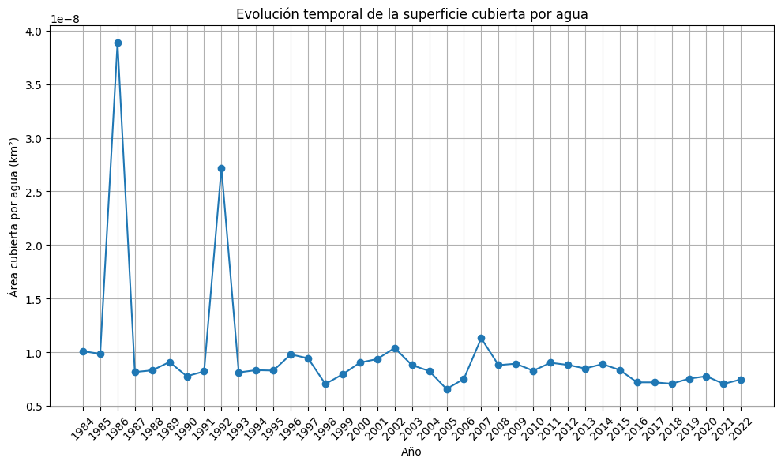

```
Área cubierta por agua por año:
     Año      Área_km2
0   1984  1.009229e-08
1   1985  9.841948e-09
2   1986  3.890370e-08
3   1987  8.144429e-09
4   1988  8.301304e-09
5   1989  9.077182e-09
6   1990  7.752895e-09
7   1991  8.203257e-09
8   1992  2.720344e-08
9   1993  8.108478e-09
10  1994  8.318299e-09
11  1995  8.283002e-09
12  1996  9.789002e-09
```

[output cut: 26 more lines]

```python
# Ordenar el DataFrame por año
df_series_tiempo.sort_values(by="Año", inplace=True)

# Graficar la serie de tiempo
plt.figure(figsize=(10, 6))
plt.plot(df_series_tiempo["Año"], df_series_tiempo["Área_km2"], marker='o', linestyle='-')
plt.title('Evolución temporal de la superficie cubierta por agua')
plt.xlabel('Año')
plt.ylabel('Área cubierta por agua (km²)')
plt.grid(True)

# Configurar los ticks del eje x para que muestren todos los años
plt.xticks(df_series_tiempo["Año"], rotation=45)

# Mostrar el gráfico
plt.tight_layout()
plt.show()

# Mostrar el DataFrame con el área calculada por año
print("Área cubierta por agua por año:")
print(df_series_tiempo)
```